# ICE development - Study 3 - data analysis

Michalina Marczak

Last compiled on 03 June, 2023

## Inspecting the climate emotions data

### Descriptives

|  | vars | n | mean | sd | median | trimmed | mad | min | max | range | skew | kurtosis | se |
| --- | --- | --- | --- | --- | --- | --- | --- | --- | --- | --- | --- | --- | --- |
| climate.anger | 1 | 239 | 3.849372 | 0.9400684 | 4.00 | 3.950777 | 1.11195 | 1 | 5 | 4 | -0.8236903 | 0.0927332 | 0.0608080 |
| climate.contempt | 2 | 239 | 2.407950 | 1.0096174 | 2.25 | 2.323834 | 1.11195 | 1 | 5 | 4 | 0.6608964 | -0.0304711 | 0.0653067 |
| climate.enthusiasm | 3 | 239 | 3.599372 | 0.8169101 | 3.75 | 3.658031 | 0.74130 | 1 | 5 | 4 | -0.7574711 | 0.4252301 | 0.0528415 |
| climate.powerlessness | 4 | 239 | 3.283473 | 0.7771209 | 3.25 | 3.323834 | 0.74130 | 1 | 5 | 4 | -0.5012505 | 0.2529005 | 0.0502678 |
| climate.guilt | 5 | 239 | 2.921548 | 0.9676306 | 3.00 | 2.965026 | 1.11195 | 1 | 5 | 4 | -0.2744229 | -0.6667040 | 0.0625908 |
| climate.isolation | 6 | 239 | 2.821130 | 0.9430547 | 3.00 | 2.818653 | 1.11195 | 1 | 5 | 4 | 0.0587578 | -0.6621222 | 0.0610011 |
| climate.anxiety | 7 | 239 | 3.610879 | 0.9403127 | 4.00 | 3.693005 | 0.74130 | 1 | 5 | 4 | -0.8687992 | 0.1356662 | 0.0608238 |
| climate.sorrow | 8 | 239 | 4.064854 | 0.8417164 | 4.25 | 4.183938 | 0.74130 | 1 | 5 | 4 | -1.2282603 | 1.3711738 | 0.0544461 |

### Distributions

#### Formal test

```
## $climate.anger
##
##  Shapiro-Wilk normality test
##
## data:  X[[i]]
## W = 0.92004, p-value = 0.0000000004786
##
##
## $climate.contempt
##
##  Shapiro-Wilk normality test
##
## data:  X[[i]]
## W = 0.94316, p-value = 0.00000005074
##
##
## $climate.enthusiasm
##
##  Shapiro-Wilk normality test
##
## data:  X[[i]]
## W = 0.94184, p-value = 0.00000003779
##
##
## $climate.powerlessness
##
##  Shapiro-Wilk normality test
##
## data:  X[[i]]
## W = 0.96874, p-value = 0.00004144
##
##
## $climate.guilt
##
##  Shapiro-Wilk normality test
##
## data:  X[[i]]
## W = 0.96677, p-value = 0.0000227
##
##
## $climate.isolation
##
##  Shapiro-Wilk normality test
##
## data:  X[[i]]
## W = 0.98014, p-value = 0.001968
##
##
## $climate.anxiety
##
##  Shapiro-Wilk normality test
##
## data:  X[[i]]
## W = 0.91516, p-value = 0.0000000002001
##
##
## $climate.sorrow
##
##  Shapiro-Wilk normality test
##
## data:  X[[i]]
## W = 0.88163, p-value = 0.000000000001055
```

### Internal consistencies

We inspect the internal consistencies of the ICE scales using Cronbach’s alpha coefficient

|  | anger | contempt | enthusiasm | powerlessness | guilt | isolation | anxiety | sorrow |
| --- | --- | --- | --- | --- | --- | --- | --- | --- |
| raw_alpha | 0.892050814049292 | 0.857519620165384 | 0.858242392709822 | 0.679712971588263 | 0.882768915185896 | 0.845797968067275 | 0.899176100707087 | 0.899513338978477 |
| std.alpha | 0.890417086788687 | 0.857609797012417 | 0.858336050474642 | 0.67831814854768 | 0.881891491107175 | 0.845717534193633 | 0.899190341256113 | 0.899953324857259 |

## Inspecting the Mental Health Continuum data

### Descriptives

|  | vars | n | mean | sd | median | trimmed | mad | min | max | range | skew | kurtosis | se |
| --- | --- | --- | --- | --- | --- | --- | --- | --- | --- | --- | --- | --- | --- |
| emo_wb | 1 | 239 | 3.948396 | 1.237689 | 4.0 | 4.008636 | 1.48260 | 1.000000 | 6 | 5.000000 | -0.4163687 | -0.6932443 | 0.0800594 |
| soc_wb | 2 | 239 | 3.195816 | 1.153649 | 3.2 | 3.180311 | 1.18608 | 1.000000 | 6 | 5.000000 | 0.0566383 | -0.7028915 | 0.0746234 |
| psy_wb | 3 | 239 | 3.992329 | 1.061842 | 4.0 | 4.034542 | 0.98840 | 1.166667 | 6 | 4.833333 | -0.3889437 | -0.3331321 | 0.0686849 |

### Distributions

#### Formal test

```
## $emo_wb
##
##  Shapiro-Wilk normality test
##
## data:  X[[i]]
## W = 0.96002, p-value = 0.000003284
##
##
## $soc_wb
##
##  Shapiro-Wilk normality test
##
## data:  X[[i]]
## W = 0.98059, p-value = 0.002326
##
##
## $psy_wb
##
##  Shapiro-Wilk normality test
##
## data:  X[[i]]
## W = 0.97851, p-value = 0.001083
```

#### Visual inspection

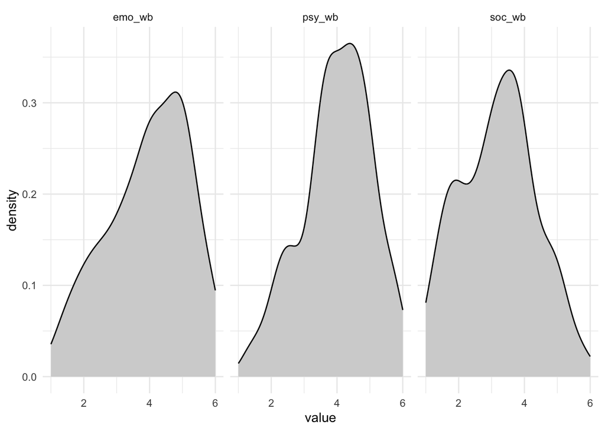

### Internal consistencies

We inspect the internal consistencies of the MHC scales using Cronbach’s alpha coefficient

|  | emo_wb | soc_wb | psy_wb |
| --- | --- | --- | --- |
| raw_alpha | 0.855735096094993 | 0.846650878994999 | 0.860443041538284 |
| std.alpha | 0.855753354854176 | 0.848789196268397 | 0.860883174998539 |

## Repeatability of climate emotions over time

### Time between measurements

```r
mean(time_between) #mean time was 216.1903 days or ~7.206343 months or 30.88433 weeks
```

```
## [1] 216.1903
```

```r
min(time_between) #minimum time was 194 days or 27.71429 weeks
```

```
## [1] 194
```

```r
max(time_between) #maximum time was 254 days or 36.28571 weeks
```

```
## [1] 254
```

### Mixed effects modelling to estimate repeatability

Based on the previous steps, we know that the data is not normally distributed so we will use the mixed effects model from the rptR package to inspect the repeatability of the ICE scores for each emotion. Using this framework, we will follow the logic of the intra-class correlation coefficient and set a 2-way mixed effects model with k = 2 mean rating and absolute agreement (Koo and Li, 2016). In order to evaluate the uncertainty in the repeatability estimate, let’s run 999 permutations for each model.

#### climate anger

```r
#run dry tests first
#rpt(value~token+(1|measure.point), grname = "measure.point", data = icc_perm, adjusted = T, datatype = c("Gaussian"), nboot = 0, npermut = 0)

#adjust for time in between
#rpt(value~token+time_between+(1|measure.point), grname = "measure.point", data = icc_perm, adjusted = T, datatype = c("Gaussian"), nboot = 0, npermut = 0)
### I get a warning: fixed-effect model matrix is rank deficient so dropping 1 column / coefficient
# This is likely because 'time_between" is reduntant in this model. I leave it out.

###Since the dry run worked fine and we see sizable repeatability, in order to evaluate the uncertainty in the repeatability estimate, and since the data is not normally distributed, I run it with 999 permutations
rpt(value~token+(1|measure.point), grname = "measure.point",
    data = icc_perm, adjusted = T, datatype = c("Gaussian"),
    nboot = 0, npermut = 999)
```

```
## Permutation Progress for measure.point :
```

```
##
##
## Repeatability estimation using the lmm method
##
## Repeatability for measure.point
## R  = 0.705
## SE =  NA
## CI = [NA, NA]
## P  = 0.0000000000000000000000000000000000000000000000000000000000000000000000000000000000000000000000000000000000000000000000191 [LRT]
##      0.001 [Permutation]
```

#### climate contempt

```
## Permutation Progress for measure.point :
```

```
##
##
## Repeatability estimation using the lmm method
##
## Repeatability for measure.point
## R  = 0.609
## SE =  NA
## CI = [NA, NA]
## P  = 0.0000000000000000000000000000000000000000000000000000000000000000000000000000000000000000000537 [LRT]
##      0.001 [Permutation]
```

#### climate enthusiasm

```
## Permutation Progress for measure.point :
```

```
##
##
## Repeatability estimation using the lmm method
##
## Repeatability for measure.point
## R  = 0.768
## SE =  NA
## CI = [NA, NA]
## P  = 0.0000000000000000000000000000000000000000000000000000000000000000000000000000000000000000000000000000000000000000000000000000000000000000000000429 [LRT]
##      0.001 [Permutation]
```

#### climate powerlessness

```
## Permutation Progress for measure.point :
```

```
##
##
## Repeatability estimation using the lmm method
##
## Repeatability for measure.point
## R  = 0.594
## SE =  NA
## CI = [NA, NA]
## P  = 0.000000000000000000000000000000000000000000000000000000000000000000000000000000000000000187 [LRT]
##      0.001 [Permutation]
```

#### climate guilt

```
## Permutation Progress for measure.point :
```

```
##
##
## Repeatability estimation using the lmm method
##
## Repeatability for measure.point
## R  = 0.679
## SE =  NA
## CI = [NA, NA]
## P  = 0.00000000000000000000000000000000000000000000000000000000000000000000000000000000000000000000000000000000000000197 [LRT]
##      0.001 [Permutation]
```

#### climate isolation

```
## Permutation Progress for measure.point :
```

```
##
##
## Repeatability estimation using the lmm method
##
## Repeatability for measure.point
## R  = 0.675
## SE =  NA
## CI = [NA, NA]
## P  = 0.0000000000000000000000000000000000000000000000000000000000000000000000000000000000000000000000000000000000000508 [LRT]
##      0.001 [Permutation]
```

#### climate anxiety

```
## Permutation Progress for measure.point :
```

```
##
##
## Repeatability estimation using the lmm method
##
## Repeatability for measure.point
## R  = 0.725
## SE =  NA
## CI = [NA, NA]
## P  = 0.00000000000000000000000000000000000000000000000000000000000000000000000000000000000000000000000000000000000000000000000000000254 [LRT]
##      0.001 [Permutation]
```

#### climate sorrow

```
## Permutation Progress for measure.point :
```

```
##
##
## Repeatability estimation using the lmm method
##
## Repeatability for measure.point
## R  = 0.711
## SE =  NA
## CI = [NA, NA]
## P  = 0.000000000000000000000000000000000000000000000000000000000000000000000000000000000000000000000000000000000000000000000000152 [LRT]
##      0.001 [Permutation]
```

## Climate emotions & mental health

### Correlation table

Let’s use the Spearman correlation coefficient because the data is ordinal and non-parametrically distributed

|  | climate.anger | climate.contempt | climate.enthusiasm | climate.powerlessness | climate.guilt | climate.isolation | climate.anxiety | climate.sorrow | emo_wb | soc_wb | psy_wb |
| --- | --- | --- | --- | --- | --- | --- | --- | --- | --- | --- | --- |
| climate.anger |  |  |  |  |  |  |  |  |  |  |  |
| climate.contempt | -0.67*** |  |  |  |  |  |  |  |  |  |  |
| climate.enthusiasm | 0.51*** | -0.48*** |  |  |  |  |  |  |  |  |  |
| climate.powerlessness | 0.41*** | -0.27*** | 0.29*** |  |  |  |  |  |  |  |  |
| climate.guilt | 0.53*** | -0.50*** | 0.45*** | 0.56*** |  |  |  |  |  |  |  |
| climate.isolation | 0.50*** | -0.24*** | 0.41*** | 0.42*** | 0.51*** |  |  |  |  |  |  |
| climate.anxiety | 0.73*** | -0.67*** | 0.58*** | 0.51*** | 0.67*** | 0.56*** |  |  |  |  |  |
| climate.sorrow | 0.78*** | -0.68*** | 0.50*** | 0.44*** | 0.54*** | 0.45*** | 0.75*** |  |  |  |  |
| emo_wb | 0.14* | -0.11 | 0.23*** | 0.01 | 0.04 | 0.06 | 0.18** | 0.13* |  |  |  |
| soc_wb | 0.19** | -0.19** | 0.42*** | 0.12 | 0.16* | 0.21** | 0.29*** | 0.19** | 0.66*** |  |  |
| psy_wb | 0.18** | -0.14* | 0.32*** | 0.03 | 0.02 | 0.12 | 0.18** | 0.17** | 0.80*** | 0.77*** |  |

## Note

This HTML output presents the general logic of the analysis along with some results not outlined in the main body of the manuscript. Please note that the full R code for the data cleaning and data analysis is available in the supplementary materials on the accompanying [OSF website](https://osf.io/78d6u).